# Compare two versions of `st_segments()`

Attilio Benini, attilio.benini@gmx.net

12 Juli, 2021

## Introduction

The R-package `nngeo` includes the function [`st_segments`](https://michaeldorman.github.io/nngeo/reference/st_segments.html) , which splits lines or polygons into separate segments. Applied to `sf` objects with a rather small number of geometries, `st_segments` works fairly handily. However, when trying to process a set of some 14’000 `LINESTRING`s, `st_segments` was still processing after several hours. To be precise, this disappointing outcome was observed with the version of `nngeo` [currently available on CRAN](https://CRAN.R-project.org/package=nngeo) and with its [latest counterpart on GitHub](https://github.com/michaeldorman/nngeo/) (both version 0.4.3).

A [forked branch of `nngeo`](https://github.com/a-benini/nngeo/tree/st_segments_efficient) modifies `st_segments()`with the objective of processing larger numbers of geometries efficiently. This is achieved by a [code modification](https://github.com/a-benini/nngeo/commit/34a33274b28f31b99b3cbd9c5d239a7c395482f4) consisting of three steps:

1. `sf::st_as_sf(data.table::rbindlist(<list_of_sf>))` replaces `do.call(rbind, <list_of_sf>)`, which speeds up compiling `<list_of_sf>` to a single `sf` object.
2. Besides its potential speed gain, `st_as_sf(rbindlist())` has a downside: Unlike `do.call(rbind, <list_of_sf>)`, it creates an object with a `bbox` identical to the `bbox` of the first element of `<list_of_sf>`. A [simple trick (`<sf> <- <sf>[1:nrow(<sf>), ]` )](https://github.com/Rdatatable/data.table/issues/4681) subsequently applied fixes this issue.
3. Finally the class `data.table` inherited from `rbindlist()`must be overwritten in order for `st_segments` to return a standard `sf`-object as output.

Below we explore the time efficiency of the two `st_segments` versions:

- `st_segments_eff`: synonym for the [forked `st_segments`](https://github.com/a-benini/nngeo/commit/34a33274b28f31b99b3cbd9c5d239a7c395482f4)
- `st_segments`: the current ‘official’ version of `nngeo`

Side notes:

- Some information / discussion on the efficiency of combining `list`s of `sf` objects to a single `dataframe` can be found [here](https://github.com/r-spatial/sf/issues/798#).
- `st_as_sf(rbindlist(``))` not only returns an object with a `bbox` identical to the `bbox` of the first element of `<list_of_sf>`, but also adopts the first element’s CRS without checking whether all elements have the same CRS. Since all generated segments originate from the same geometry set, the argument `x`, this isn’t an issue here. Else a prior checking of CRS-uniformity would be necessary.

## Packages required

```r
library(dplyr)
library(tibble)
library(tidyr)
library(stringr)
library(ggplot2)
library(sf)
library(data.table)
library(microbenchmark)
library(kableExtra)
```

External dependencies versions of the libraries linked to `sf`:

```r
sf::sf_extSoftVersion()
```

```
##           GEOS           GDAL         proj.4 GDAL_with_GEOS     USE_PROJ_H
##        "3.9.0"        "3.2.0"        "7.2.0"         "true"         "true"
##           PROJ
##        "7.2.0"
```

## Two versions of `st_segments()`

### `st_segments_eff`

The a.m. forked branch of `nngeo` can be found at https://github.com/a-benini/nngeo/tree/st_segments_efficient (forked from https://github.com/michaeldorman/nngeo/). It contains [the very version of `st_segments()`](https://github.com/a-benini/nngeo/commit/34a33274b28f31b99b3cbd9c5d239a7c395482f4) that should be more efficient than the currently available developer version. The corresponding function code is saved here as `st_segments_eff`:

```r
st_segments_eff <- function(x, progress = TRUE) {

  # Get or transform to geometry
  geom = st_geometry(x)

  # Get attributes
  if(class(x)[1] == "sf") dat = st_drop_geometry(x) else dat = NULL

  # Progress bar
  if(progress) pb = utils::txtProgressBar(min = 0, max = length(geom), initial = 0, style = 3)

  # For each feature...
  final = list()
  for(i in 1:length(geom)) {

    # Progress
    if(progress) utils::setTxtProgressBar(pb, i)

    # Current geometry
    geom1 = geom[i]

    # Cast LINESTRING
    if(st_is(geom1, "MULTIPOLYGON")) geom1 = st_cast(geom1, "POLYGON")
    line = st_cast(geom1, "LINESTRING")

    result = list()
    # For each LINESTRING...
    for(j in 1:length(line)) {

      # Split to segments
      pnt = st_cast(line[j], "POINT")

      # For each segment...
      tmp = list()
      for(k in 1:(length(pnt)-1)) {
        tmp[[k]] = pnt[c(k, k+1)]
      }
      tmp = lapply(tmp, st_combine)
      tmp = lapply(tmp, st_cast, "LINESTRING")
      tmp = do.call(c, tmp)
      result[[j]] = tmp

    }

    # Combine
    result = do.call(c, result)

    # Add attributes
    if(!is.null(dat)) result = st_sf(result, dat[i, , drop = FALSE])

    # Add to 'final'
    final[[i]] = result

  }

  # Progress
  if(progress) cat("\n")

  # Combine
  if(!is.null(dat)) {
    final = st_as_sf(data.table::rbindlist(final))
    final = final[1:nrow(final), ]
    class(final) = c("sf", "data.frame")
  } else {
    final = do.call(c, final)
  }

  # Return result
  return(final)
  }
```

### `st_segments`

Install `nngeo` version 0.4.3 from CRAN:

```r
devtools::install_version(
  "nngeo", version = "0.4.3", repos = "http://cran.us.r-project.org",
  force = TRUE, quiet = TRUE
  )
library(nngeo)
packageVersion("nngeo")
```

```
## [1] '0.4.3'
```

## Check of versions of `st_segments()`

Check if the two versions of `st_segments()` differ:

```r
all.equal(st_segments_eff, st_segments)
## [1] "target, current do not match when deparsed"
```

Get some polygons to tryout the two versions of `st_segments()`:

```r
nc <- st_read(system.file("gpkg/nc.gpkg", package = "sf"), quiet = TRUE)
```

Check if the two versions of `st_segments()` return the same output:

```r
nc_seg_eff <- st_segments_eff(nc, FALSE)
nc_seg     <- st_segments(nc, FALSE)
all.equal(nc_seg_eff, nc_seg)
## [1] TRUE
```

## Run-time of versions of `st_segments()`

`list` some `sf` objects with different numbers of geometries (`n`):

```r
n <- c(10, seq(100, 1000, 100))
set.seed(1234)
l <- lapply(n, function(x) dplyr::slice_sample(nc, n = x, replace = TRUE))
```

Get run times of `st_segments()` and `st_segments_eff()` when applied to each `list`ed `sf` object:

```r
t0 <- Sys.time()
l_mircobenchmark <- lapply(
  l,
  function(x) {
    microbenchmark(
      st_segments(x, FALSE),
      st_segments_eff(x, FALSE),
      times = 5L
      )
    }
  )
Sys.time() - t0
```

```
## Time difference of 43.29152 mins
```

Table mean run times:

```r
cap_text <- "Means of overall and per geometry processing times for combinations of numbers of geometries (n) and function versions."
tibble(n, l_mircobenchmark) %>%
  unnest(l_mircobenchmark) %>%
  group_by(n, expr) %>%
  summarise(time = mean(time), .groups = "drop") %>%
  mutate(
    time = time / 10^9, # convert nanoseconds into seconds
    time_per_geom = time / n # mean time per input geometry
  ) %>%
  pivot_wider(names_from = expr, values_from = c(time, time_per_geom)) %>%
  setNames(., names(.) %>% str_remove_all("time_|per_geom_|(x, FALSE)")) %>%
  kable("html", caption = cap_text, digits = 3) %>%
  kable_styling(position = "left", font_size = 12, full_width = FALSE) %>%
  add_header_above(c(" " = 1, "overall" = 2, "per input geometry" = 2)) %>%
  add_header_above(c(" ", "mean run time [s]" = 4))
```

Table 1: Means of overall and per geometry processing times for combinations of numbers of geometries (n) and function versions.

| n | mean run time [s] overall st_segments() | mean run time [s] overall st_segments_eff() | mean run time [s] per input geometry st_segments() | mean run time [s] per input geometry st_segments_eff() |
| --- | --- | --- | --- | --- |
| 10 | 0.196 | 0.200 | 0.020 | 0.020 |
| 100 | 2.443 | 1.465 | 0.024 | 0.015 |
| 200 | 6.777 | 2.865 | 0.034 | 0.014 |
| 300 | 12.915 | 4.232 | 0.043 | 0.014 |
| 400 | 21.278 | 5.626 | 0.053 | 0.014 |
| 500 | 30.351 | 6.838 | 0.061 | 0.014 |
| 600 | 40.993 | 8.130 | 0.068 | 0.014 |
| 700 | 56.910 | 9.795 | 0.081 | 0.014 |
| 800 | 71.250 | 11.301 | 0.089 | 0.014 |
| 900 | 87.467 | 12.324 | 0.097 | 0.014 |
| 1000 | 111.118 | 14.751 | 0.111 | 0.015 |

Plot run times:

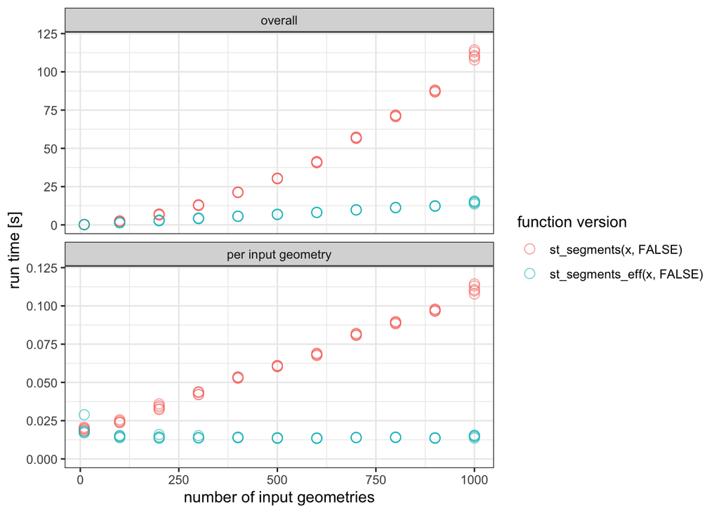

Figure 1: Number of geometries of an input `sf` object vs. run time of `st_segments()` and `st_segments_eff()`.

```r
tibble(n, l_mircobenchmark) %>%
  unnest(l_mircobenchmark) %>%
  mutate(
    overall = time / 10^9, # convert nanoseconds into seconds
    `per input geometry` = overall / n, # mean time per input geometry
    time = NULL
  ) %>%
  pivot_longer(-c(n, expr), names_to = "key", values_to = "time") %>%
  ggplot(aes(x = n, y = time, col = expr)) +
  geom_point(shape = 1, alpha = 0.6, size = 3) +
  facet_wrap(vars(key), ncol = 1, scales = "free_y") +
  scale_y_continuous(limits = function(y) {c(0, max(y) * 1.05)} ) +
  labs(x = "number of input geometries", y = "run time [s]", col = "function version") +
  theme_bw()
```

## Conclusions

The above plot (figure 1) reveals the following:

- In the case of `sf` objects with very few geometries `st_segment_eff` does not always process faster than `st_segment`. But this hardly ever matters, for one way or the other overall run times are anyhow quite minor.
- With rising numbers of geometries of a processed `sf` object the overall time efficiency of `st_segment_eff` outperforms the one of `st_segment`.
- `st_segment`’s run time seems to respond somewhat exponentially to the number of geometries of a `sf` input, whereas `st_segment_eff` appears to follow a steady slope.
- Quite obviously `st_segment`’s run time per input geometry rises with the numbers of input geometries. By contrast, in the case of `st_segment_eff` this metric is more or less constant.

Thus it is sound to say that replacing `do.call(rbind, <list_of_sf>)` with `sf::st_as_sf(data.table::rbindlist(<list_of_sf>))` does not only reduce the overall processing time, it also tackles the issue of exponentially more time consuming processing when it comes to handling `sf` objects with increasing numbers of geometries.

Experience made so far has shown that `st_segment_eff` is capable of processing a `sf` object of some 95’000 `LINESTRING`s within about 8 minutes. This corresponds to approximately 0.005 seconds per geometry, which is about 1/3 of the run time required in the above demonstration (s. table 1). This difference in performance is most likely due to, on average, a rather small number segments originating from each `LINESTRING`. Thus besides the number of geometries, their complexity appears to dictate also the run time (on a given operation system / computer). So one may want to diagnose the time span of `st_segment_eff` applied to a sample of a large set of geometries before running the whole set in order to roughly estimate processing time.